# Single-Person Household Product Analysis

E-Readers, Coffee Machines & Microwaves in Swiss Cantons

# Executive Summary

This analysis investigates the correlation between the proportion of single-person households and sales of three product categories in Swiss cantons: - **E-Readers** (481 sales) - **Coffee Machines** (170 sales) - **Microwaves** (145 sales)

**Research question**: Which of these products shows the strongest correlation with single-person household rates?

**Hypothesis**: Products typically used by individuals living alone will show higher per-capita sales in cantons with more single-person households.

# 1. Data & Method

We analyze sales data from Digitec Galaxus for three product categories and compare them with single-person household rates across Swiss cantons.

**Product categories**: 1. **E-Readers** (ereader-1138): Digital reading devices - potentially popular with solo readers 2. **Coffee Machines** (kaffeevollautomat-125): Single-serve capability - convenient for one person 3. **Microwaves** (mikrowelle-130): Quick individual meals - typical for solo living

**Data sources**: - Product sales by canton (Digitec Galaxus) - Single-person household rates and population by canton (BFS 2024)

**Method**: Pearson correlation between single-person household percentage and sales per 5,000 residents for each product category.

# 2. Data Preparation

```r
# Load packages
library(tidyverse)
library(readr)
library(ggplot2)
library(knitr)
library(corrplot)

options(scipen = 999)
theme_set(theme_minimal())
```

```r
# Load household data
household_data <- read_delim("Einpersonenhaushalt.csv",
                             delim = ";",
                             locale = locale(encoding = "UTF-8"))

# Rename columns for easier handling
colnames(household_data) <- c("Canton_ID", "Canton", "Single_Household_Pct", "Population")

# Load sales data
sales_data <- read_csv("DigitecLive_Cleaned.csv",
                       locale = locale(encoding = "UTF-8"))

kable(household_data,
      digits = 1,
      format.args = list(big.mark = "'"),
      caption = "Single-Person Household Rates by Canton")
```

Single-Person Household Rates by Canton

| Canton_ID | Canton | Single_Household_Pct | Population |
| --- | --- | --- | --- |
| 1 | Zürich | 37.2 | 1’620’020 |
| 10 | Freiburg | 33.8 | 346’674 |
| 11 | Solothurn | 36.3 | 289’792 |
| 12 | Basel-Stadt | 47.8 | 201’384 |
| 13 | Basel-Landschaft | 35.2 | 301’323 |
| 14 | Schaffhausen | 38.7 | 88’667 |
| 15 | Appenzell Ausserrhoden | 35.8 | 56’705 |
| 16 | Appenzell Innerrhoden | 32.1 | 16’733 |
| 17 | St. Gallen | 36.2 | 540’036 |
| 18 | Graubünden | 39.9 | 206’138 |
| 19 | Aargau | 33.4 | 735’808 |
| 2 | Bern | 38.5 | 1’071’216 |
| 20 | Thurgau | 34.5 | 299’509 |
| 21 | Tessin | 42.1 | 358’903 |
| 22 | Waadt | 38.4 | 855’106 |
| 23 | Wallis | 38.6 | 371’288 |
| 24 | Neuenburg | 42.2 | 179’518 |
| 25 | Genf | 38.0 | 531’102 |
| 26 | Jura | 39.0 | 74’840 |
| 3 | Luzern | 35.1 | 437’944 |
| 4 | Uri | 34.1 | 38’275 |
| 5 | Schwyz | 33.6 | 168’931 |
| 6 | Obwalden | 34.0 | 39’662 |
| 7 | Nidwalden | 34.3 | 45’345 |
| 8 | Glarus | 37.1 | 42’371 |
| 9 | Zug | 32.4 | 133’739 |

```r
# Filter for three product categories
ereader_sales <- sales_data %>%
  filter(`infos.Category` == "ereader-1138")

coffee_sales <- sales_data %>%
  filter(`infos.Category` == "kaffeevollautomat-125")

microwave_sales <- sales_data %>%
  filter(`infos.Category` == "mikrowelle-130")

# Display sample counts
cat("E-Readers:", nrow(ereader_sales), "sales\n")
```

```
E-Readers: 481 sales
```

```r
cat("Coffee Machines:", nrow(coffee_sales), "sales\n")
```

```
Coffee Machines: 170 sales
```

```r
cat("Microwaves:", nrow(microwave_sales), "sales\n")
```

```
Microwaves: 145 sales
```

```r
cat("\nUnique cantons in data:", length(unique(sales_data$canton)), "\n")
```

```
Unique cantons in data: 26
```

# 3. Results

```r
# Prepare canton mapping
canton_mapping <- c(
  "ZH" = "Zürich", "BE" = "Bern", "LU" = "Luzern", "UR" = "Uri",
  "SZ" = "Schwyz", "OW" = "Obwalden", "NW" = "Nidwalden", "GL" = "Glarus",
  "ZG" = "Zug", "FR" = "Freiburg", "SO" = "Solothurn", "BS" = "Basel-Stadt",
  "BL" = "Basel-Landschaft", "SH" = "Schaffhausen", "AR" = "Appenzell Ausserrhoden",
  "AI" = "Appenzell Innerrhoden", "SG" = "St. Gallen", "GR" = "Graubünden",
  "AG" = "Aargau", "TG" = "Thurgau", "TI" = "Tessin", "VD" = "Waadt",
  "VS" = "Wallis", "NE" = "Neuenburg", "GE" = "Genf", "JU" = "Jura"
)

# Function to aggregate sales by canton
aggregate_by_canton <- function(sales_df, product_name) {
  sales_df %>%
    group_by(canton) %>%
    summarise(Total_Sales = n(), .groups = 'drop') %>%
    mutate(Canton_Full = canton_mapping[canton]) %>%
    select(Canton_Full, Total_Sales) %>%
    rename(!!product_name := Total_Sales)
}

# Aggregate each product category
ereader_agg <- aggregate_by_canton(ereader_sales, "EReader_Sales")
coffee_agg <- aggregate_by_canton(coffee_sales, "Coffee_Sales")
microwave_agg <- aggregate_by_canton(microwave_sales, "Microwave_Sales")

# Merge all products with household data
analysis_data <- household_data %>%
  left_join(ereader_agg, by = c("Canton" = "Canton_Full")) %>%
  left_join(coffee_agg, by = c("Canton" = "Canton_Full")) %>%
  left_join(microwave_agg, by = c("Canton" = "Canton_Full")) %>%
  mutate(
    EReader_Sales = replace_na(EReader_Sales, 0),
    Coffee_Sales = replace_na(Coffee_Sales, 0),
    Microwave_Sales = replace_na(Microwave_Sales, 0),
    EReader_per_5k = (EReader_Sales / Population) * 5000,
    Coffee_per_5k = (Coffee_Sales / Population) * 5000,
    Microwave_per_5k = (Microwave_Sales / Population) * 5000
  )

kable(analysis_data %>%
        select(Canton, Single_Household_Pct, EReader_per_5k, Coffee_per_5k, Microwave_per_5k) %>%
        arrange(desc(Single_Household_Pct)),
      digits = 2,
      col.names = c("Canton", "Single HH %", "E-Reader", "Coffee", "Microwave"),
      caption = "Product Sales per 5,000 Residents by Canton")
```

Product Sales per 5,000 Residents by Canton

| Canton | Single HH % | E-Reader | Coffee | Microwave |
| --- | --- | --- | --- | --- |
| Basel-Stadt | 47.8 | 0.35 | 0.02 | 0.10 |
| Neuenburg | 42.2 | 0.11 | 0.03 | 0.14 |
| Tessin | 42.1 | 0.25 | 0.01 | 0.04 |
| Graubünden | 39.9 | 0.32 | 0.12 | 0.02 |
| Jura | 39.0 | 0.07 | 0.20 | 0.00 |
| Schaffhausen | 38.7 | 0.06 | 0.06 | 0.11 |
| Wallis | 38.6 | 0.19 | 0.07 | 0.00 |
| Bern | 38.5 | 0.19 | 0.10 | 0.09 |
| Waadt | 38.4 | 0.25 | 0.08 | 0.05 |
| Genf | 38.0 | 0.19 | 0.11 | 0.14 |
| Zürich | 37.2 | 0.43 | 0.09 | 0.10 |
| Glarus | 37.1 | 0.24 | 0.12 | 0.00 |
| Solothurn | 36.3 | 0.28 | 0.09 | 0.09 |
| St. Gallen | 36.2 | 0.17 | 0.13 | 0.12 |
| Appenzell Ausserrhoden | 35.8 | 0.35 | 0.18 | 0.00 |
| Basel-Landschaft | 35.2 | 0.27 | 0.07 | 0.08 |
| Luzern | 35.1 | 0.19 | 0.09 | 0.07 |
| Thurgau | 34.5 | 0.20 | 0.17 | 0.15 |
| Nidwalden | 34.3 | 0.11 | 0.11 | 0.00 |
| Uri | 34.1 | 0.13 | 0.26 | 0.00 |
| Obwalden | 34.0 | 0.38 | 0.13 | 0.25 |
| Freiburg | 33.8 | 0.20 | 0.04 | 0.07 |
| Schwyz | 33.6 | 0.27 | 0.15 | 0.00 |
| Aargau | 33.4 | 0.37 | 0.14 | 0.06 |
| Zug | 32.4 | 0.26 | 0.07 | 0.11 |
| Appenzell Innerrhoden | 32.1 | 0.00 | 0.00 | 0.00 |

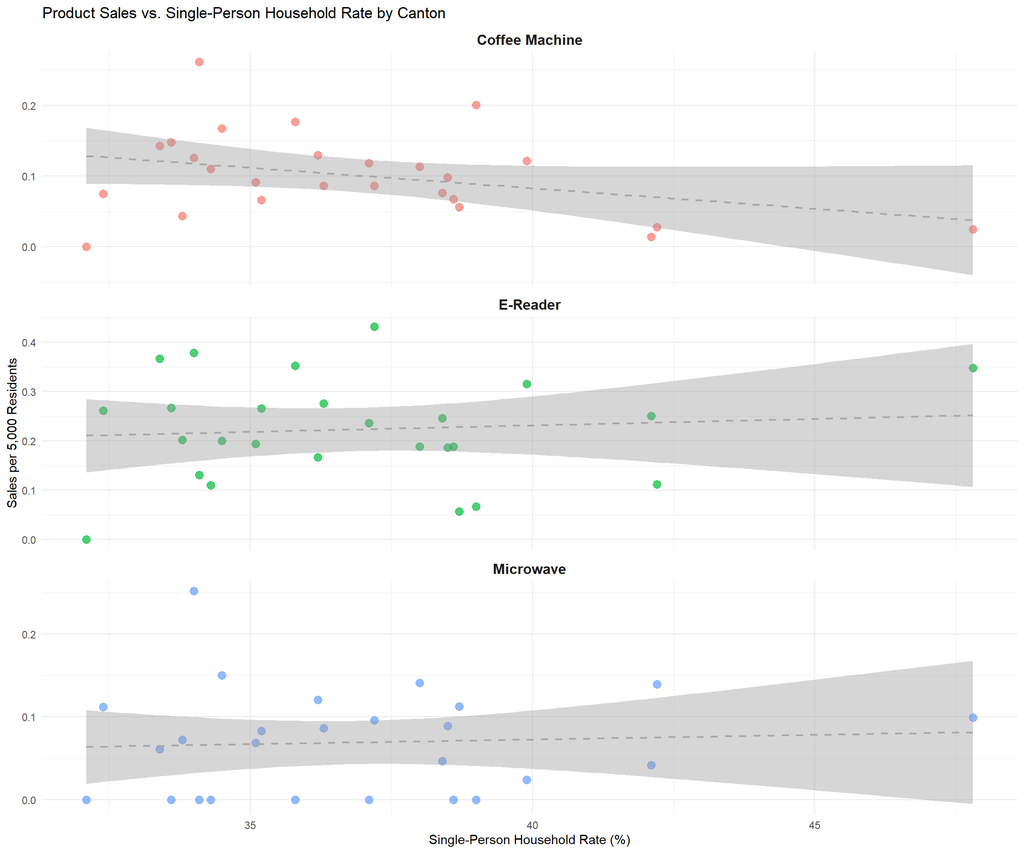

```r
# Prepare data for plotting
plot_data <- analysis_data %>%
  select(Canton, Single_Household_Pct, EReader_per_5k, Coffee_per_5k, Microwave_per_5k) %>%
  pivot_longer(
    cols = c(EReader_per_5k, Coffee_per_5k, Microwave_per_5k),
    names_to = "Product",
    values_to = "Sales_per_5k"
  ) %>%
  mutate(Product = case_when(
    Product == "EReader_per_5k" ~ "E-Reader",
    Product == "Coffee_per_5k" ~ "Coffee Machine",
    Product == "Microwave_per_5k" ~ "Microwave"
  ))

# Visualization with facets
ggplot(plot_data, aes(x = Single_Household_Pct, y = Sales_per_5k)) +
  geom_point(aes(color = Product), size = 3, alpha = 0.7) +
  geom_smooth(method = "lm", se = TRUE, color = "darkgray", linetype = "dashed", linewidth = 0.8) +
  facet_wrap(~Product, scales = "free_y", ncol = 1) +
  labs(
    title = "Product Sales vs. Single-Person Household Rate by Canton",
    x = "Single-Person Household Rate (%)",
    y = "Sales per 5,000 Residents"
  ) +
  theme_minimal() +
  theme(
    legend.position = "none",
    strip.text = element_text(size = 12, face = "bold")
  )
```

```r
# Correlation analysis for all three products
cor_ereader <- cor.test(analysis_data$Single_Household_Pct, analysis_data$EReader_per_5k)
cor_coffee <- cor.test(analysis_data$Single_Household_Pct, analysis_data$Coffee_per_5k)
cor_microwave <- cor.test(analysis_data$Single_Household_Pct, analysis_data$Microwave_per_5k)

# Create summary table
correlation_summary <- data.frame(
  Product = c("E-Reader", "Coffee Machine", "Microwave"),
  Correlation = c(cor_ereader$estimate, cor_coffee$estimate, cor_microwave$estimate),
  P_Value = c(cor_ereader$p.value, cor_coffee$p.value, cor_microwave$p.value),
  Significant = c(
    ifelse(cor_ereader$p.value < 0.05, "Yes", "No"),
    ifelse(cor_coffee$p.value < 0.05, "Yes", "No"),
    ifelse(cor_microwave$p.value < 0.05, "Yes", "No")
  )
)

kable(correlation_summary,
      digits = 4,
      col.names = c("Product", "Correlation (r)", "p-value", "Significant (p<0.05)"),
      caption = "Correlation Results: Single-Person Households vs. Product Sales")
```

Correlation Results: Single-Person Households vs. Product Sales

| Product | Correlation (r) | p-value | Significant (p<0.05) |
| --- | --- | --- | --- |
| E-Reader | 0.0872 | 0.6720 | No |
| Coffee Machine | -0.3405 | 0.0888 | No |
| Microwave | 0.0626 | 0.7611 | No |

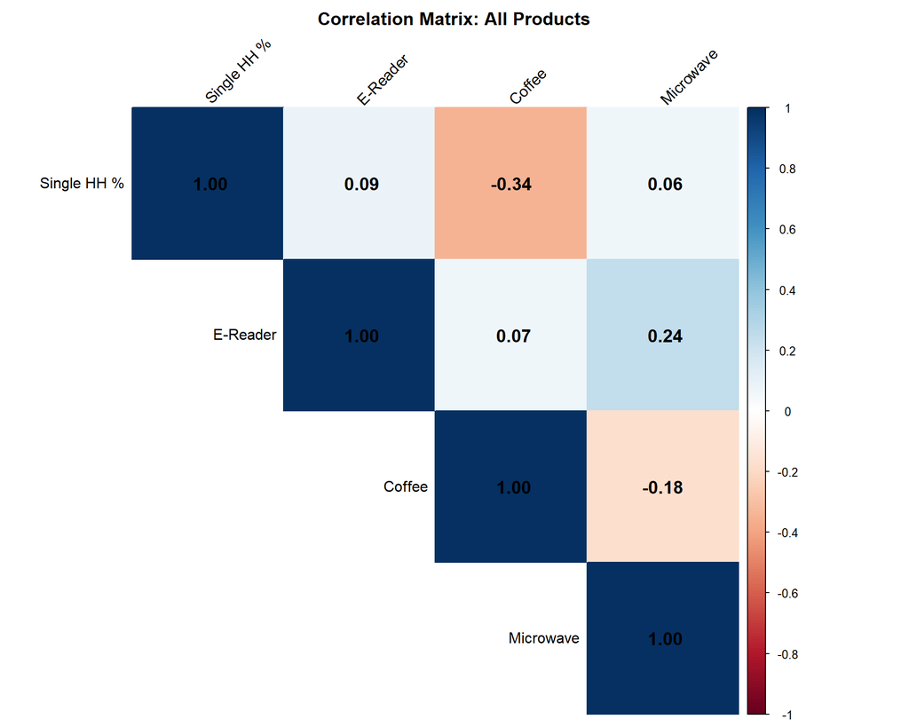

```r
# Correlation matrix for all variables
cor_data <- analysis_data %>%
  select(Single_Household_Pct, EReader_per_5k, Coffee_per_5k, Microwave_per_5k)

colnames(cor_data) <- c("Single HH %", "E-Reader", "Coffee", "Microwave")

cor_matrix <- cor(cor_data, use = "complete.obs")

corrplot(cor_matrix,
         method = "color",
         type = "upper",
         addCoef.col = "black",
         tl.col = "black",
         tl.srt = 45,
         number.cex = 1.2,
         title = "Correlation Matrix: All Products",
         mar = c(0, 0, 2, 0))
```

```r
# Canton ranking by single-household rate
ranking <- analysis_data %>%
  select(Canton, Single_Household_Pct, EReader_per_5k, Coffee_per_5k, Microwave_per_5k) %>%
  arrange(desc(Single_Household_Pct))

kable(ranking,
      digits = 2,
      col.names = c("Canton", "Single HH %", "E-Reader", "Coffee", "Microwave"),
      caption = "Canton Ranking by Single-Household Rate with Product Sales per 5k")
```

Canton Ranking by Single-Household Rate with Product Sales per 5k

| Canton | Single HH % | E-Reader | Coffee | Microwave |
| --- | --- | --- | --- | --- |
| Basel-Stadt | 47.8 | 0.35 | 0.02 | 0.10 |
| Neuenburg | 42.2 | 0.11 | 0.03 | 0.14 |
| Tessin | 42.1 | 0.25 | 0.01 | 0.04 |
| Graubünden | 39.9 | 0.32 | 0.12 | 0.02 |
| Jura | 39.0 | 0.07 | 0.20 | 0.00 |
| Schaffhausen | 38.7 | 0.06 | 0.06 | 0.11 |
| Wallis | 38.6 | 0.19 | 0.07 | 0.00 |
| Bern | 38.5 | 0.19 | 0.10 | 0.09 |
| Waadt | 38.4 | 0.25 | 0.08 | 0.05 |
| Genf | 38.0 | 0.19 | 0.11 | 0.14 |
| Zürich | 37.2 | 0.43 | 0.09 | 0.10 |
| Glarus | 37.1 | 0.24 | 0.12 | 0.00 |
| Solothurn | 36.3 | 0.28 | 0.09 | 0.09 |
| St. Gallen | 36.2 | 0.17 | 0.13 | 0.12 |
| Appenzell Ausserrhoden | 35.8 | 0.35 | 0.18 | 0.00 |
| Basel-Landschaft | 35.2 | 0.27 | 0.07 | 0.08 |
| Luzern | 35.1 | 0.19 | 0.09 | 0.07 |
| Thurgau | 34.5 | 0.20 | 0.17 | 0.15 |
| Nidwalden | 34.3 | 0.11 | 0.11 | 0.00 |
| Uri | 34.1 | 0.13 | 0.26 | 0.00 |
| Obwalden | 34.0 | 0.38 | 0.13 | 0.25 |
| Freiburg | 33.8 | 0.20 | 0.04 | 0.07 |
| Schwyz | 33.6 | 0.27 | 0.15 | 0.00 |
| Aargau | 33.4 | 0.37 | 0.14 | 0.06 |
| Zug | 32.4 | 0.26 | 0.07 | 0.11 |
| Appenzell Innerrhoden | 32.1 | 0.00 | 0.00 | 0.00 |

# 4. Conclusion

**Research Question**: Which product shows the strongest correlation with single-person household rates?

**Results**: - **E-Reader**: r = 0.087, p = 0.672 - NOT SIGNIFICANT - **Coffee Machine**: r = -0.34, p = 0.0888 - NOT SIGNIFICANT - **Microwave**: r = 0.063, p = 0.7611 - NOT SIGNIFICANT

**Key Findings**: - Canton with highest single-household rate: Basel-Stadt (47.8%) - Strongest correlation product: Coffee Machine

**Interpretation**: No significant correlations found. The Coffee Machine shows the strongest (negative) relationship with single-person households.

**Possible explanations**: 1. **Urban lifestyle**: Higher single-household rates in cities correlate with different consumer behaviors 2. **Demographics**: Age and income of people living alone influence product preferences 3. **Living space**: Smaller apartments may drive demand for compact appliances 4. **Independence**: Solo living requires individual-sized appliances and personal devices

**Data**: Digitec Galaxus (E-Readers, Coffee Machines, Microwaves), BFS (Single-Person Households 2024)